# Introduction to SC19077

## Question 2: T7.10,P213

In Example 7.18, leave-one-out (n-fold) cross validation was used to select the best fitting model. Repeat the analysis replacing the Log-Log model with a cubic polynomial model. Which of the four models is selected by the cross validation procedure? Which model is selected according to maximum adjusted R2?

```r
library(DAAG)
attach(ironslag)
modl <- c("Linear","Quadratic","Exponential","CubicPolynomial")

which.best <- function(dat){
  n <- length(dat[,1])

  y1 <- y2 <- y3 <- y4 <- numeric(n)
  for (i in 1:n){
    x <- dat[-i,1]
    y <- dat[-i,2]
    x0 <- dat[i,1]

    cv1 <- lm( y ~ x )
    a1 <- cv1$coef
    y1[i] <- a1[1] + a1[2]*x0

    cv2 <- lm( y ~ x + I(x^2))
    a2 <- cv2$coef
    y2[i] <- a2[1] + a2[2]*x0 + a2[3]*x0^2

    cv3 <- lm( log(y) ~ x)
    a3 <- cv3$coef
    y3[i] <- exp( a3[1] + a3[2]*x0 )

    cv4 <- lm( y ~ poly(x,degree=3))
    a4 <- cv4$coef
    y4[i] <- a4[1] + a4[2]*x0 + a4[3]*x0^2 + a4[4]*x0^3
  }
  y <- cbind(y1,y2,y3,y4)

  Y <- dat[,2]
  e <- numeric(4)
  for (i in 1:4)e[i] <- mean((Y-y[,i])^2)

  SST <- sum((Y - mean(Y))^2)
  SSR <- numeric(4)
  for (i in 1:4)SSR[i] <- sum((Y-y[,i])^2)
  k <- c(1,2,1,3)
  R2 <- SSR/SST
  adjR2 <- (1-(1-R2))*(n-1)/(n-k-1)

  num <- c(which.min(e),which.max(adjR2))
  return(c(CrossValidation=modl[num[1]],adjustedR2=modl[num[2]]))
}

which.best(ironslag)
```

```
##   CrossValidation        adjustedR2
##       "Quadratic" "CubicPolynomial"
```

#### Question: T9.3,P277

Implement a random walk Metropolis sampler for generating the standard Laplace distribution $f(x)={1\over2}e^{-|x|}$(see Exercise 3.2). For the increment, simulate from a normal distribution. Compare the chains generated when different variances are used for the proposal distribution. Also, compute the acceptance rates of each chain.

#### Answer

Implement the random walk version of the Metropolis sampler to generate the target standard Laplace distribution, using the proposal distribution Normal($Xt$, $\sigma^2$).

```r
library(GeneralizedHyperbolic)
rw.Metropolis <- function(x0,N,sigma){
  x <- numeric(N)
  x[1] <- x0
  u <- runif(N)
  k <- 0
  for (i in 2:N){
    y <- rnorm(1,x[i-1],sigma)
    if (u[i] <= dskewlap(y) / dskewlap(x[i-1]))
      x[i] <- y
    else{
      x[i] <- x[i-1]
      k <- k+1

    }
  }
  return(list(x=x,k=k))
}

sigma <- c(.05,.1,seq(.2,1,.4),seq(2,6,1),10)
n <- length(sigma)
N <- 2000
x0 <- rnorm(1)
rw <- matrix(nrow=N,ncol=n)
Num_of_Reject <- numeric(n)
for (i in 1:n){
 rw[,i] <- rw.Metropolis(x0,N,sigma[i])$x
 Num_of_Reject[i] <- rw.Metropolis(x0,N,sigma[i])$k
}
```

The acceptance rate is as follows:

```r
Accept_Rate <- round(1-Num_of_Reject/N,3)
knitr::kable(rbind(Num_of_Reject,Accept_Rate),formate="html",col.names=c("0.05","0.1","0.2","0.6","1","2","3","4","5","6","10"))
```

|  | 0.05 | 0.1 | 0.2 | 0.6 | 1 | 2 | 3 | 4 | 5 | 6 | 10 |
| --- | --- | --- | --- | --- | --- | --- | --- | --- | --- | --- | --- |
| Num_of_Reject | 34.000 | 84.000 | 152.000 | 393.000 | 618.000 | 959.00 | 1210.000 | 1319.00 | 1434.000 | 1547.000 | 1686.000 |
| Accept_Rate | 0.983 | 0.958 | 0.924 | 0.804 | 0.691 | 0.52 | 0.395 | 0.34 | 0.283 | 0.227 | 0.157 |

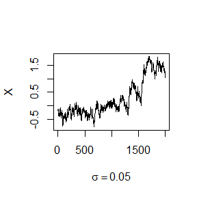

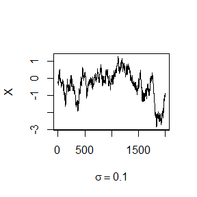

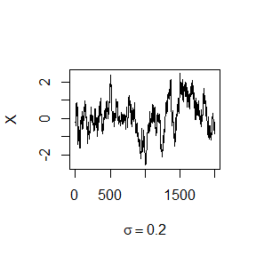

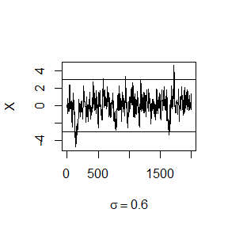

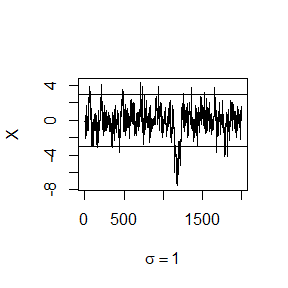

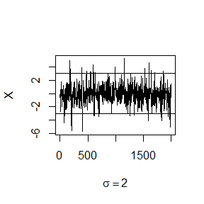

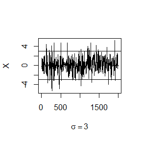

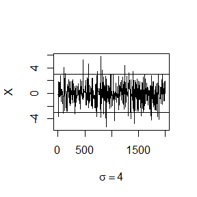

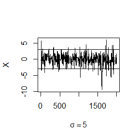

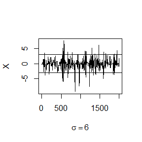

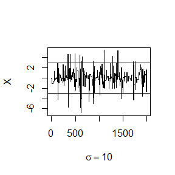

```r
refline <- qskewlap(c(.025,.975))
for (i in 1:n){
  plot(1:N,rw[,i],type="l",xlab=bquote(sigma==.(sigma[i])),ylab="X")
  abline(h=refline)
}
```

From the figures above we can see:  
a)the chains didn’t converge when $\sigma < 0.6$;  
b)when $\sigma > 2$ there are many short horizontal paths in the graph in which the candidate point is rejected and the chain didn’t move at these time points.

In conclusion, if we want to implement a random walk Metropolis sampler for generating the standard Laplace distribution with normal proposal distribution, we’d better choose standard deviation with $0.6 \leq \sigma \leq2$.

### Question 1:T11.1,P353

The natural logarithm and exponential functions are inverses of each other, so that mathematically log(exp x) = exp(log x) = x. Show by example that this property does not hold exactly in computer arithmetic. Does the identity hold with near equality? (See all.equal.)

### Answer1

```r
isTRUE(exp(log(.001))==.001)
```

```
## [1] FALSE
```

```r
isTRUE(log(exp(.001))==.001)
```

```
## [1] FALSE
```

```r
isTRUE(log(exp(.001))==exp(log(.001)))
```

```
## [1] FALSE
```

```r
isTRUE(all.equal(log(exp(.001)),.001))
```

```
## [1] TRUE
```

```r
isTRUE(all.equal(exp(log(.001)),.001))
```

```
## [1] TRUE
```

```r
isTRUE(all.equal(exp(log(.001)),log(exp(.001))))
```

```
## [1] TRUE
```

In the example above I choose $x=0.001$. And $e^{ln(0.001)}$ and $ln e^{0.001}$ should be the same in the mathematical calculation but not in the computer arithmetic. Hence the function “isTRUE” returned “FALSE”. However, with near equality the identity holds and the function “isTRUE” with “all.equal” returned “TRUE”.

### Quesion 2:T11.5,P355

> Write a function to solve the equation
> $$\frac{2\Gamma\left(\frac{k}{2}\right)}{\sqrt{\pi(k-1)}\Gamma\left(\frac{k-1}{2}\right)}\int_{0}^{c_{k-1}}\left(1+\frac{u^{2}}{k-1}\right)^{-k/2}du =\frac{2\Gamma\left(\frac{k+1}{2}\right)}{\sqrt{\pi k}\Gamma\left(\frac{k}{2}\right)} \int_{0}^{c_{k}}\left(1+\frac{u^{2}}{k}\right)^{-(k+1)/2}du$$
> for a, where $c_{k}=\sqrt{\frac{a^{2} k}{k+1-a^{2}}}$. Compare the solutions with the points $A(k)$ in Exercise 11.4. $$

```r
#####11.4
K <- c(4:25,100,500,1e3)
UP <- sqrt(K)
n <- length(K)
A <- numeric(n)

for (i in 1:n){
  k <- K[i]
  f <- function(a){
   pt(sqrt(a^2*(k-1)/(k-a^2)),k-1) - pt(sqrt(a^2*k/(k+1-a^2)),k)
  }
  a <- UP[i]/2+1
  out <- uniroot(f,c(0.5,a))
  A[i] <- out$root
}
```

```r
### 11.5
K1 <- c(4:25,100)
n1 <- length(K1)
B <- numeric(n1)

ck <- function(k,a)sqrt((k*(a^2))/(k+1-a^2))
integ_f1 <- function(u)(1+(u^2)/(k-1))^(-k/2)
integ_f2 <- function(u)(1+(u^2)/k)^((-1-k)/2)

f <- function(a){
gamma(k/2)/(gamma((k-1)/2)*sqrt(k-1))*integrate(integ_f1,0,ck(k-1,a))$value-gamma((k+1)/2)/(gamma(k/2)*sqrt(k))*integrate(integ_f2,0,ck(k,a))$value
}

for (i in 1:n1){
  k <- K1[i]
  B[i] <- uniroot(f,lower=0.05,upper=(sqrt(k)/2+1))$root
}
```

```r
A <- round(A[1:n1],4)
B <- round(B,4)
err <- A-B

f <- data.frame(rbind(A,B,err),row.names=c("11.4","11.5","error"))
knitr::kable(f)
```

|  | X1 | X2 | X3 | X4 | X5 | X6 | X7 | X8 | X9 | X10 | X11 | X12 | X13 | X14 | X15 | X16 | X17 | X18 | X19 | X20 | X21 | X22 | X23 |
| --- | --- | --- | --- | --- | --- | --- | --- | --- | --- | --- | --- | --- | --- | --- | --- | --- | --- | --- | --- | --- | --- | --- | --- |
| 11.4 | 1.4921 | 1.5336 | 1.5628 | 1.5844 | 1.6012 | 1.6145 | 1.6254 | 1.6344 | 1.6421 | 1.6485 | 1.6542 | 1.6591 | 1.6634 | 1.6673 | 1.6707 | 1.6738 | 1.6766 | 1.6792 | 1.6815 | 1.6836 | 1.6855 | 1.6874 | 1.7206 |
| 11.5 | 1.4921 | 1.5336 | 1.5627 | 1.5844 | 1.6012 | 1.6145 | 1.6254 | 1.6344 | 1.6420 | 1.6485 | 1.6542 | 1.6591 | 1.6634 | 1.6673 | 1.6707 | 1.6738 | 1.6766 | 1.6792 | 1.6815 | 1.6836 | 1.6855 | 1.6874 | 1.7206 |
| error | 0.0000 | 0.0000 | 0.0001 | 0.0000 | 0.0000 | 0.0000 | 0.0000 | 0.0000 | 0.0001 | 0.0000 | 0.0000 | 0.0000 | 0.0000 | 0.0000 | 0.0000 | 0.0000 | 0.0000 | 0.0000 | 0.0000 | 0.0000 | 0.0000 | 0.0000 | 0.0000 |

### Question 3

> Let the three alleles be A, B, and O with allele frequencies p, q, and r. The 6 genotype frequencies under HWE and complete counts are as follows.

| Genotype | AA | BB | OO | AO | BO | AB | Sum |
| --- | --- | --- | --- | --- | --- | --- | --- |
| Frequency | $p^2$ | $q^2$ | $r^2$ | 2pr | 2qr | 2pq | 1 |
| Count | $n_{AA}$ | $n_{BB}$ | $n_{OO}$ | $n_{AO}$ | $n_{BO}$ | $n_{AB}$ | n |

- Observed data:
  - $n_{A·}=n_{AA}+n_{AO}$=28(A-type),
  - $n_{B·}=n_{BB}+n_{BO}$=24(B-type),
  - $n_{OO}$=41(O-type),
  - $n_{AB}$=70(AB-type).
- Use EM algorithm to solve MLE of p and q (consider missing data $n_{AA}$ and $n_{BB}$).
- Show that the log-maximum likelihood values in M-steps are increasing via line plot.

### Answer 3

```r
library(rootSolve)
r <- 1e3
n1 <- 28
n2 <- 24
n3 <- 41
n4 <- 70
p0 <- .1
q0 <- .1
L <- c(.1,.1)
tol <- .Machine$double.eps^0.5
L.old <- L+1
logML <- numeric(r)
for(j in 1:r){
  logML[j] <- 2*p0*n1*log(p0)/(2-p0-2*q0)+2*q0*n2*log(q0)/(2-q0-2*p0)+2*n3*log(1-p0-q0)+n1*(2-2*p0-2*q0)*log(2*p0*(1-p0-q0))/(2-p0-2*q0)+n2*(2-2*p0-2*q0)*log(2*q0*(1-p0-q0))/(2-q0-2*p0)+n4*log(2*p0*q0)
  g <- function(x){
    F1 <- 2*p0*n1/((2-p0-2*q0)*x[1])-2*n3/(1-x[1]-x[2])+n1*(2-2*p0-2*q0)*(1-2*x[1]-x[2])/((2-p0-2*q0)*x[1]*(1-x[1]-x[2]))-n2*(2-2*p0-2*q0)/((2-q0-2*p0)*(1-x[1]-x[2]))+n4/x[1]
    F2 <- 2*q0*n2/((2-q0-2*p0)*x[2])-2*n3/(1-x[1]-x[2])-n1*(2-2*p0-2*q0)/((2-p0-2*q0)*(1-x[1]-x[2]))+n2*(2-2*p0-2*q0)*(1-2*x[2]-x[1])/((2-q0-2*p0)*x[2]*(1-x[1]-x[2]))+n4/x[2]
    c(F1=F1,F2=F2)
  }
  ss=multiroot(f=g,star=c(.1,.1))
  L=ss$root
  if (sum(abs(L-L.old)/L.old)<tol) break
  L.old <- L
}
L.old
```

```
## [1] 0.3056658 0.2926741
```

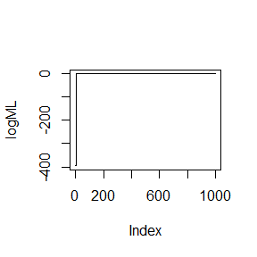

```r
plot(logML,type = "l")
```

```r
knitr::opts_chunk$set(echo = TRUE)
```

### Question 1:AR,P204,T3

Use both for loops and lapply() to fit linear models to the mtcars using the formulas stored in this list: formulas <- list( mpg ~ disp, mpg ~ I(1 / disp), mpg ~ disp + wt, mpg ~ I(1 / disp) + wt )

### Answer 1

```r
attach(mtcars)
formulas <- list(
  mpg ~ disp,
  mpg ~ I(1 / disp),
  mpg ~ disp + wt,
  mpg ~ I(1 / disp) + wt
)

#lapply
##version 1
lm_result1 <- lapply(formulas,function(x)lm(x))
##version 2
lm_result1 <- lapply(formulas,lm,data=mtcars)

#for
lm_result2 <- vector("list",length(formulas))
for (i in seq_along(formulas))lm_result2[[i]] <- lm(formulas[[i]])

#coefficients
l_int <- round(sapply(lm_result1,function(x)x$coefficients[1]),3)
l_coef <- round(sapply(lm_result1,function(x)x$coefficients[2]),3)
f_int <- round(sapply(lm_result2,function(x)x$coefficients[1]),3)
f_coef <- round(sapply(lm_result2,function(x)x$coefficients[2]),3)
```

### Question 2:AR,P204,T4

Fit the model mpg ~ disp to each of the bootstrap replicates of mtcars in the list below by using a for loop and lapply(). Can you do it without an anonymous function? bootstraps <- lapply(1:10, function(i) { rows <- sample(1:nrow(mtcars), rep = TRUE) mtcars[rows, ] })

### Answer 2

```r
attach(mtcars)
bootstraps <- lapply(1:10, function(i) {
  rows <- sample(1:nrow(mtcars), rep = TRUE)
  mtcars[rows, ]
})

#for
results1 <- vector("list",length(bootstraps))
for(i in seq_along(bootstraps)){
  mt <- bootstraps[[i]]
  results1[[i]] <- lm(mt[,1]~mt[,3])
}

#lapply
results2 <- lapply(bootstraps,function(x)lm(x[,1]~x[,3]))

#coefficients
f_intercpt <- f_coef <- numeric(length(results1))
for(i in seq_along(bootstraps)){
  f_intercpt[i] <- results1[[i]]$coefficients[1]
  f_coef[i] <- results1[[i]]$coefficients[2]
}
round(f_intercpt,3)
```

```
##  [1] 29.653 29.217 30.228 28.543 30.898 29.175 27.978 32.835 28.612 28.907
```

```r
round(f_coef,3)
```

```
##  [1] -0.044 -0.043 -0.045 -0.039 -0.044 -0.041 -0.036 -0.055 -0.035 -0.037
```

```r
#without anonymous function
results4 <- lapply(bootstraps,lm,formula=mpg~disp)
```

### Question 3:AR,P204,T5

For each model in the previous two exercises, extract R2 using the function below. rsq <- function(mod) summary(mod)$r.squared

### Answer 3

```r
rsq <- function(mod) summary(mod)$r.squared

#T3
t3 <- sapply(lm_result1,rsq)
round(t3,3)
```

```
## [1] 0.718 0.860 0.781 0.884
```

```r
#T4
t4 <- sapply(results1,rsq)
round(t4,3)
```

```
##  [1] 0.723 0.763 0.787 0.770 0.710 0.637 0.628 0.774 0.632 0.687
```

### Question 4:AR,P214,T3

The following code simulates the performance of a t-test for non-normal data. Use sapply() and an anonymous function to extract the p-value from every trial. trials <- replicate(100,t.test(rpois(10, 10), rpois(7, 10)),simplify = FALSE) Extra challenge: get rid of the anonymous function by using [[ directly.

### Answer 4

```r
trials <- replicate(100,t.test(rpois(10, 10), rpois(7, 10)),simplify = FALSE)
p_result1 <- sapply(trials,function(x)x$p.value)
round(p_result1[1:10],3)
```

```
##  [1] 0.336 0.533 0.577 0.200 0.047 0.570 0.402 0.317 0.337 0.360
```

```r
p_result2 <- sapply(trials,"[[","p.value")
round(p_result2[1:10],3)
```

```
##  [1] 0.336 0.533 0.577 0.200 0.047 0.570 0.402 0.317 0.337 0.360
```

### Question 5:AR,P214,T7

Implement mcsapply(), a multicore version of sapply(). Can you implement mcvapply(), a parallel version of vapply()? Why or why not?

### Answer 5

```r
library(parallel)
cores <- detectCores(logical = FALSE)
cl <- makeCluster(getOption("cl.cores", cores))
parSapply(cl, 1:500, get("+"), 3)[1:10]
```

```
##  [1]  4  5  6  7  8  9 10 11 12 13
```

As for whether we can implement a parallel version of vapply(), my answer is NO. The condition for parallelisation is that each iteration is isolated from all others(See P212,Advanced R),that is when we scrambl the order of elements of X and iterate in sequence, the answer is always the same.

To make this clear, we can see the explanation code of lapply() in Advanced R:

```r
lapply2 <- function(x, f, ...) {
  out <- vector("list", length(x))
  for (i in seq_along(x))out[[i]] <- f(x[[i]], ...)
  out
}
```

When we scramble the order of computation, the explanation code of apply() becomes:(caution:the order of computation changes because of function “sample”)

```r
lapply3 <- function(x, f, ...) {
  out <- vector("list", length(x))
  for (i in sample(seq_along(x)))out[[i]] <- f(x[[i]], ...)
  out
}
```

However, the result is the same as before so lapply() has its parallel mclapply(). So is function slapply().

But for vapply(), the example below shows that when the order of computation changes, the result of vapply() may be changed.

```r
x <- 1:10
y <- rep("a",10)
df1 <- data.frame(x,y)
df2 <- data.frame(y,x)
vapply(df1,class,FUN.VALUE=character(1))
```

```
##         x         y
## "integer"  "factor"
```

```r
vapply(df2,class,FUN.VALUE=character(1))
```

```
##         y         x
##  "factor" "integer"
```

The result changes so vapply() can’t have its parallelisation mcvapply().

```r
knitr::opts_chunk$set(echo = TRUE)
```

### Question

1. You have already written an R function for Exercise 9.4 (page 277, Statistical Computing with R).Rewrite an Rcpp function for the same task.

9.4 Implement a random walk Metropolis sampler for generating the standard Laplace distribution (see Exercise 3.2). For the increment, simulate from a normal distribution. Compare the chains generated when different variances are used for the proposal distribution. Also, compute the acceptance rates of each chain.

```r
## r
library(GeneralizedHyperbolic)
rw.Metropolis <- function(x0,N,sigma){
  x <- numeric(N)
  x[1] <- x0
  u <- runif(N)
  k <- 0
  for (i in 2:N){
    y <- rnorm(1,x[i-1],sigma)
    if (u[i] <= dskewlap(y) / dskewlap(x[i-1]))
      x[i] <- y
    else{
      x[i] <- x[i-1]
      k <- k+1
    }
  }
  return(list(x=x,k=k))
}
```

```r
## C++
library(Rcpp)

### generate random numbers
cppFunction('NumericVector rwMetropolisC(double x0, int N, double sigma){
  NumericVector xC(N);
  xC[0] = x0;
  NumericVector u = runif(N);
  int k = 0;
  for(int i = 1; i < N; i++) {
    double y = (rnorm(1,xC[i-1],sigma))[0];
    double res = exp(abs(xC[i-1]) - abs(y));
    if(u[i] < res){
      xC[i] = y;
    }
    else{
      xC[i] = xC[i-1];
      k ++;}
    };
  return xC;}')

### generate k
cppFunction('int rw_k_C(double x0, int N, double sigma){
  NumericVector xC(N);
  xC[0] = x0;
  NumericVector u = runif(N);
  int k = 0;
  for(int i = 1; i < N; i++) {
    double y = (rnorm(1,xC[i-1],sigma))[0];
    double res = exp(abs(xC[i-1]) - abs(y));
    if(u[i] < res){
      xC[i] = y;
    }
    else{
      xC[i] = xC[i-1];
      k ++;}
    };
  return k;}')
```

2. Compare the generated random numbers by the two functions using qqplot.

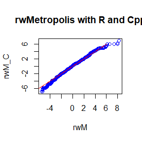

```r
rw.Metropolis <- function(x0,N,sigma){
  x <- numeric(N)
  x[1] <- x0
  u <- runif(N)
  k <- 0
  for (i in 2:N){
    y <- rnorm(1,x[i-1],sigma)
    if (u[i] <= dskewlap(y) / dskewlap(x[i-1]))
      x[i] <- y
    else{
      x[i] <- x[i-1]
      k <- k+1
    }
  }
  return(list(x=x,k=k))
}

sigma <- c(.1,.5,2,5,10)
n <- length(sigma)
N <- 2000
x0 <- rnorm(1)
rwM <- matrix(nrow=N,ncol=n)
rwM_C <- matrix(nrow=N,ncol=n)
Num_of_Reject <- numeric(n)
Num_of_Reject_C <- numeric(n)
for (i in 1:n){
 rwM[,i] <- rw.Metropolis(x0,N,sigma[i])$x
 Num_of_Reject[i] <- rw.Metropolis(x0,N,sigma[i])$k
 rwM_C[,i] <- rwMetropolisC(x0,N,sigma[i])
 Num_of_Reject_C[i] <- rw_k_C(x0,N,sigma[i])
}
Accept_rate_R <- round(1-Num_of_Reject/N,3)
Accept_rate_Cpp <- round(1-Num_of_Reject_C/N,3)

#compare random numbers
qqplot(rwM, rwM_C, xlab = deparse(substitute(rwM)),ylab = deparse(substitute(rwM_C)),main="rwMetropolis with R and Cpp",col="blue")
x <- seq(-6,6,.05)
lines(x,x,col="red")
```

```r
#compare accept rate
knitr::kable(rbind(Accept_rate_R,Accept_rate_Cpp),formate="html",col.names=c("0.1","0.5","2","5","10"))
```

|  | 0.1 | 0.5 | 2 | 5 | 10 |
| --- | --- | --- | --- | --- | --- |
| Accept_rate_R | 0.967 | 0.822 | 0.530 | 0.294 | 0.146 |
| Accept_rate_Cpp | 0.970 | 0.881 | 0.552 | 0.308 | 0.176 |

3. Campare the computation time of the two functions with microbenchmark.

```r
library(microbenchmark)
ts <- list(n)
for (i in 1:n){
 times <- microbenchmark(rwM=rw.Metropolis(x0,N,sigma[i])$x,
 rwM_C=rwMetropolisC(x0,N,sigma[i]))
 ts[[i]] <- summary(times)[,c(1,3,5,6)]
}
ts
```

```
## [[1]]
##    expr       lq  median      uq
## 1   rwM 17615.15 19091.1 20742.9
## 2 rwM_C   178.25   185.7   192.2
##
## [[2]]
##    expr       lq   median       uq
## 1   rwM 16959.20 17953.20 20375.85
## 2 rwM_C   204.75   211.75   220.15
##
## [[3]]
##    expr       lq  median       uq
## 1   rwM 16979.15 17958.0 20268.00
## 2 rwM_C   247.10   256.8   266.75
##
## [[4]]
##    expr       lq   median       uq
## 1   rwM 16705.30 17431.75 19952.05
## 2 rwM_C   251.35   259.55   266.95
##
## [[5]]
##    expr      lq   median      uq
## 1   rwM 16751.7 17833.35 20066.9
## 2 rwM_C   251.9   259.00   266.3
```

From the qqplot we can see that the random numbers generated from R and C++ respectively are approximately lining near the line $y=x$ which indicates that these two groups of data are from the same distribution.